# Базовые стратегии торговли опционами

(примеры графиков)

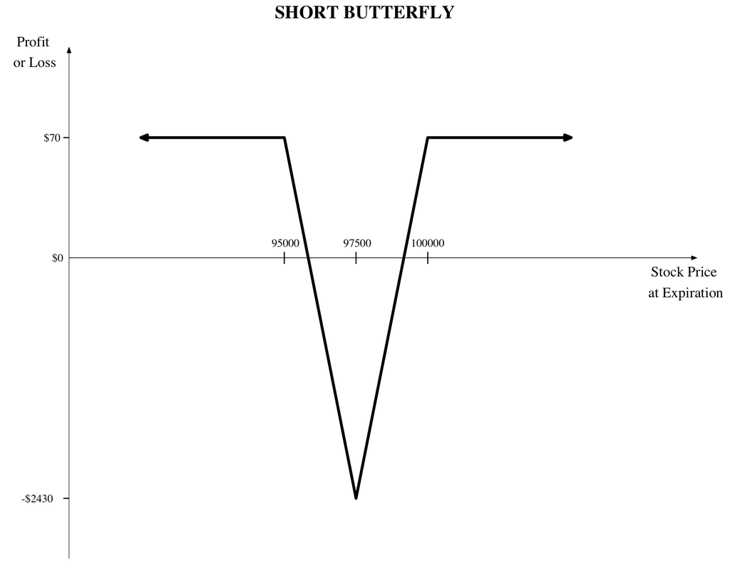

**Рис. 1.1** Short Butterfly состоит из опционов с тремя разными ценами исполнения,  
но одинаковым сроком истечения контрактов.[^1]

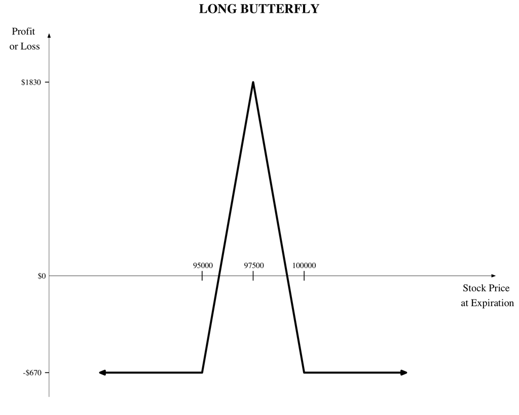

**Рис. 1.2** Long Butterfly состоит из опционов с тремя разными ценами исполнения,  
но одинаковым сроком истечения контрактов.[^2]

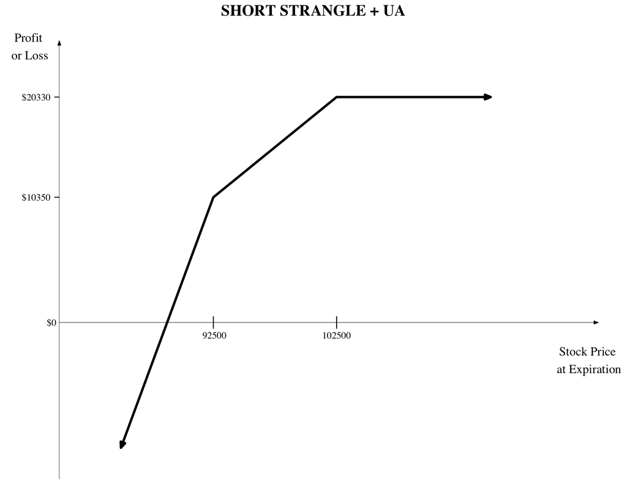

**Рис. 1.3** Short Strangle + UA.

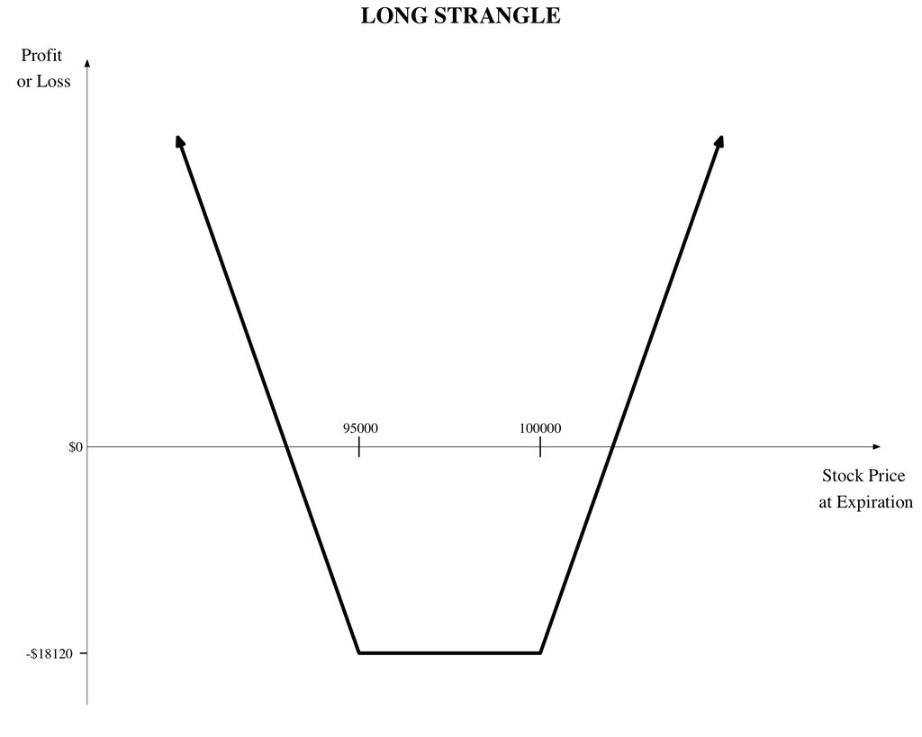

**Рис. 1.4** Long Strangle cтратегия заключается в покупке опционов колл и пут с одним сроком истечения контрактов, но разными ценами исполнения.[^3]

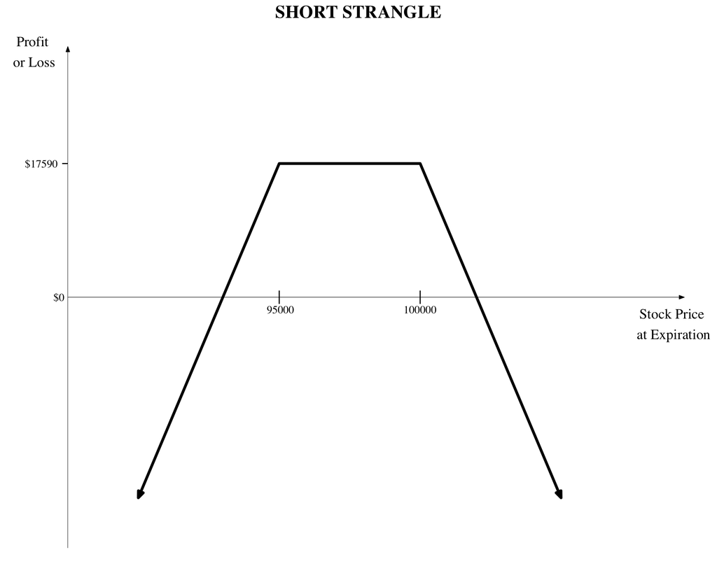

**Рис. 1.5** Short Strangle стратегия заключается в продаже опционов колл и пут с одним сроком истечения контрактов, но разными ценами исполнения.[^4]

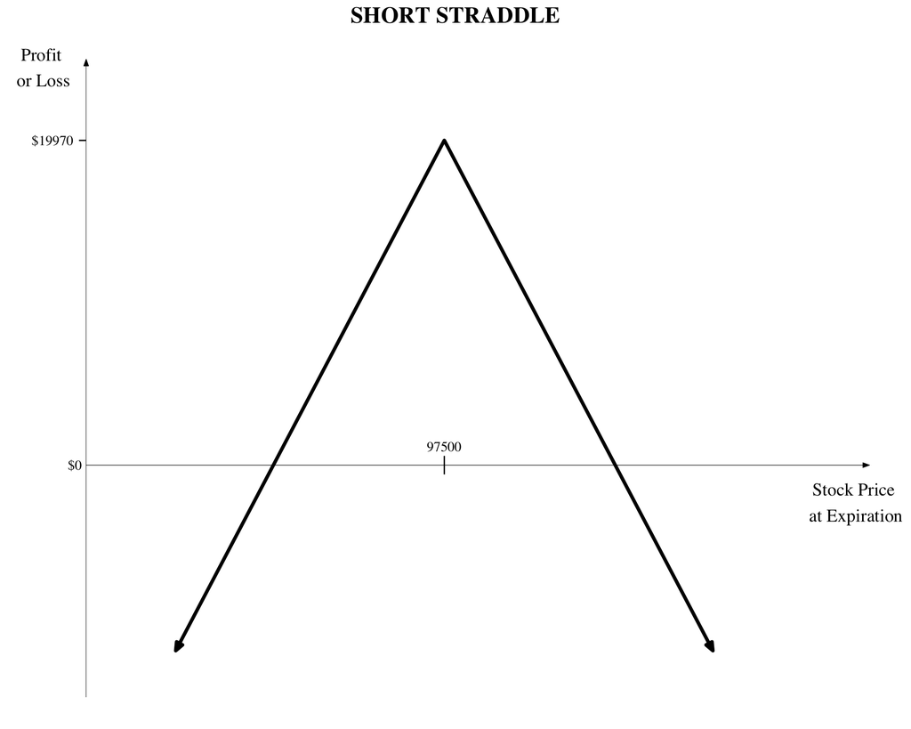

**Рис. 1.6** Short Straddle стратегия заключается в продаже опционов пут и колл с одинаковой ценой исполнения и датой истечения контрактов.[^5]

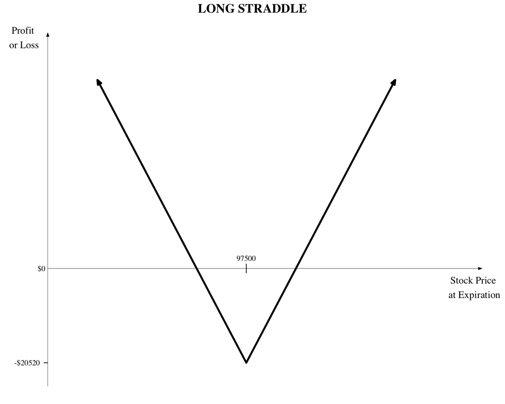

**Рис. 1.7** Long Straddle стратегия заключается в покупке опционов пут и колл с одинаковой ценой исполнения и датой истечения контрактов.[^6]

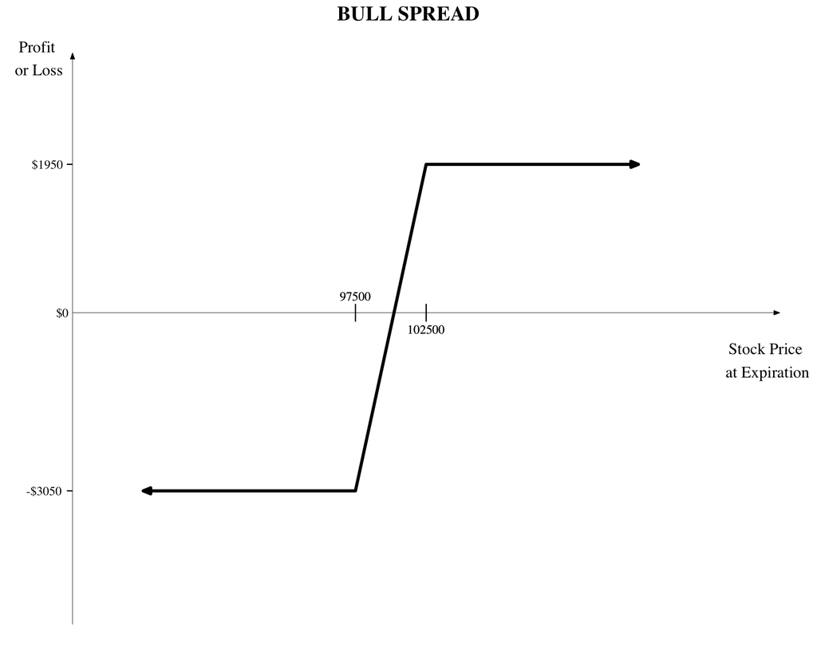

**Рис. 1.8** Bull Spread заключается в продаже и покупке опционов колл с одной датой истечения, но разными ценами исполнения.[^7]

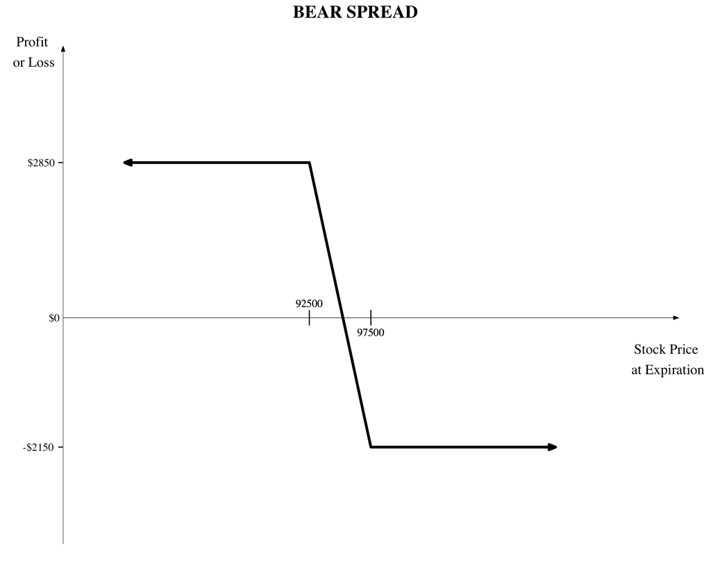

**Рис. 1.9** Bear Spread заключается в продаже и покупке опционов колл с одной датой истечения, но разными ценами исполнения.[^8]

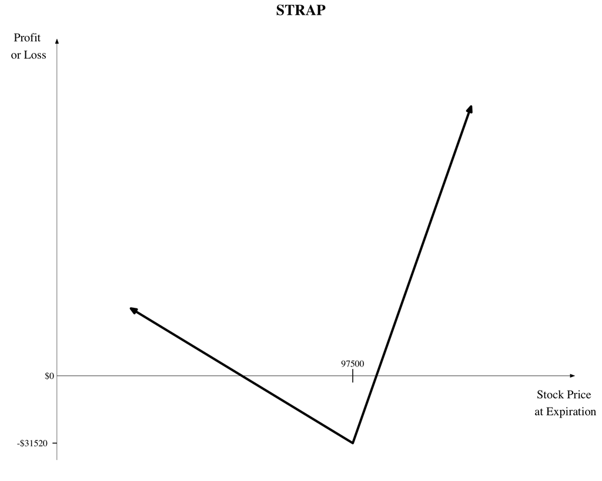

**Рис. 1.10** Strap заключается в покупке пута и двух опционов колл с одинаковой датой истечения контрактов, цены исполнения могут быть одинаковыми или разными.[^9]

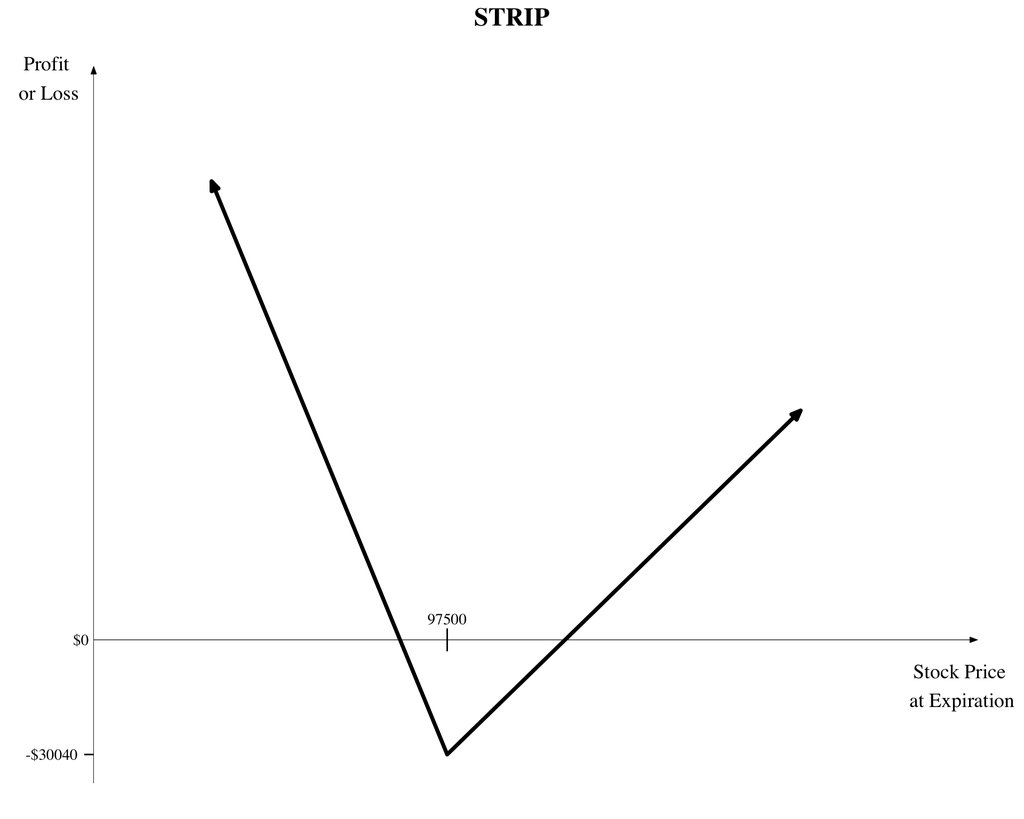

**Рис. 1.11** Strip заключается в покупке колла и двух опционов пут с одинаковой датой истечения контрактов, а цены исполнения могут быть одинаковыми или разными.[^10]

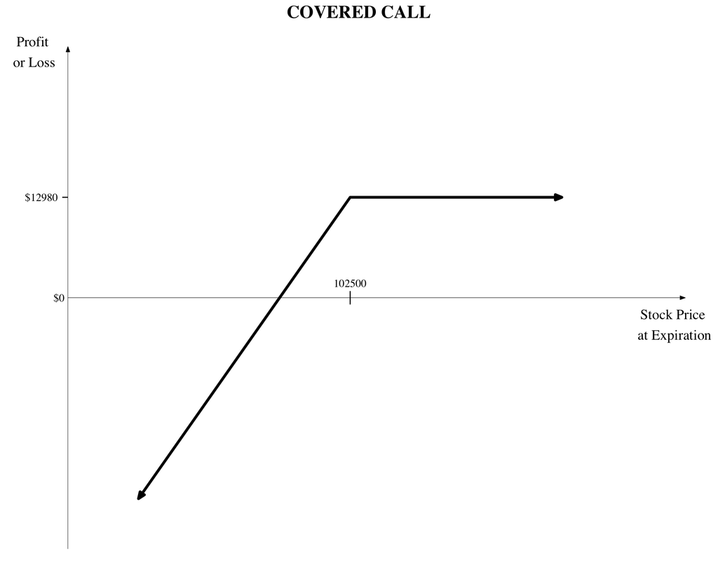

**Рис. 1.12** Covered Call заключается в продаже определенного количества опционов колл на уже существующий базовой актив (например, фьючерс на индекс РТС или доллар/рубль).[^11]

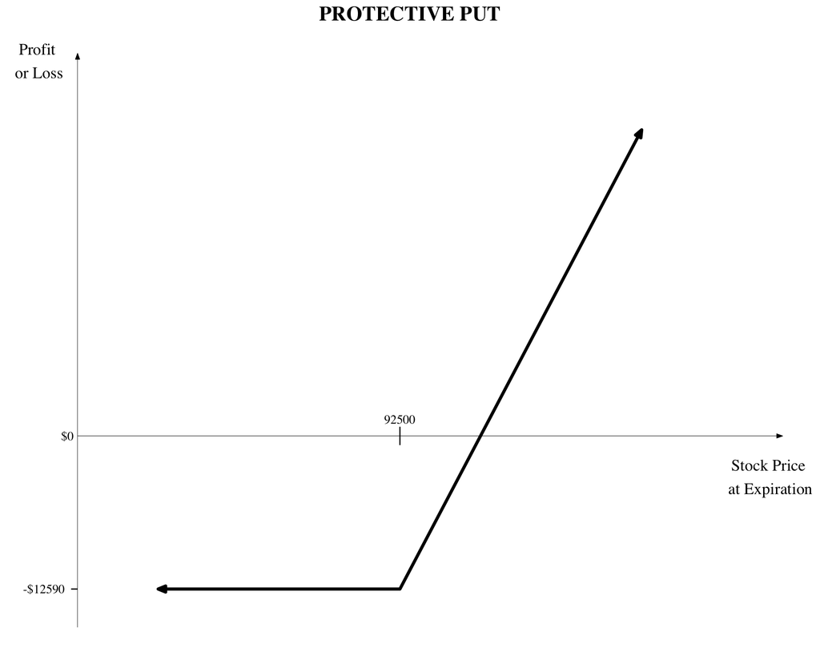

**Рис. 1.13** Protective Put схож со стратегией Long Call. Убыток ограничивается уплаченной за опцион премией, в то время как есть потенциал получить неограниченную прибыль.[^12]

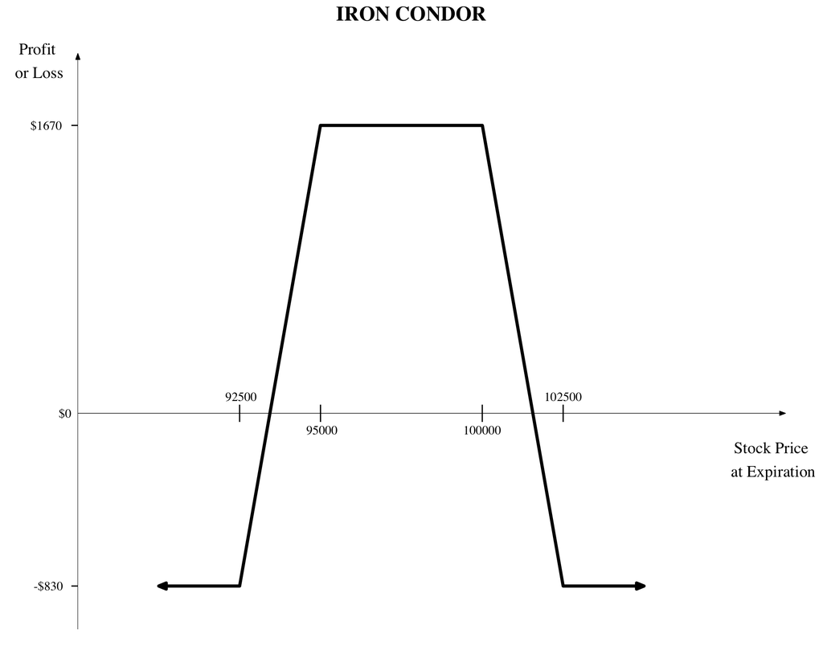

**Рис. 1.14** Iron Condor состоит из четырех опционов колл или пут с одной датой истечения контрактов, но разными ценами исполнения. Чаще применяется на опционах колл, но возможно и использование путов, а также комбинации коллов и путов.[^13]

### Ссылки на источники

[^1]: http://www.option.ru/glossary/strategy/short-butterfly
[^2]: http://www.option.ru/glossary/strategy/long-butterfly
[^3]: http://www.option.ru/glossary/strategy/long-strangle
[^4]: http://www.option.ru/glossary/strategy/short-strangle
[^5]: http://www.option.ru/glossary/strategy/short-straddle
[^6]: http://www.option.ru/glossary/strategy/long-straddle
[^7]: http://www.option.ru/glossary/strategy/bull-call-spread
[^8]: http://www.option.ru/glossary/strategy/bear-call-spread
[^9]: http://www.option.ru/glossary/strategy/strap
[^10]: http://www.option.ru/glossary/strategy/strip
[^11]: https://optionsworld.ru/pokrytyj-opcion-koll-covered-call/
[^12]: https://xdirect.ua/study/options/klassicheskie-opcionnye-strategii/protective-callprotective-put
[^13]: http://www.option.ru/glossary/articles/lyetim-na-zhyelyeznom-kondorye